# CD data mining assignment

Jamison Orton

2026-05-27

# 1 Libraries

```r
library(rmarkdown)
library(psych)
library(scatterplot3d)
library(caret)
library(tidyverse)
```

## 1.1 Import a csv file

```r
cd <- read.csv(file = "CD_additional_balanced.csv", stringsAsFactors = FALSE)
cd %>% str()
```

```
## 'data.frame':    9280 obs. of  21 variables:
##  $ age           : int  41 49 49 41 45 42 39 28 44 42 ...
##  $ job           : chr  "blue-collar" "entrepreneur" "technician" "technician" ...
##  $ marital       : chr  "divorced" "married" "married" "married" ...
##  $ education     : chr  "basic.4y" "university.degree" "basic.9y" "professional.course" ...
##  $ default       : chr  "unknown" "unknown" "no" "unknown" ...
##  $ housing       : chr  "yes" "yes" "no" "yes" ...
##  $ loan          : chr  "no" "no" "no" "no" ...
##  $ contact       : chr  "telephone" "telephone" "telephone" "telephone" ...
##  $ month         : chr  "may" "may" "may" "may" ...
##  $ day_of_week   : chr  "mon" "mon" "mon" "mon" ...
##  $ duration      : int  1575 1042 1467 579 461 673 935 1201 1030 1623 ...
##  $ campaign      : int  1 1 1 1 1 2 3 1 1 1 ...
##  $ pdays         : int  999 999 999 999 999 999 999 999 999 999 ...
##  $ previous      : int  0 0 0 0 0 0 0 0 0 0 ...
##  $ poutcome      : chr  "nonexistent" "nonexistent" "nonexistent" "nonexistent" ...
##  $ emp.var.rate  : num  1.1 1.1 1.1 1.1 1.1 1.1 1.1 1.1 1.1 1.1 ...
##  $ cons.price.idx: num  94 94 94 94 94 ...
##  $ cons.conf.idx : num  -36.4 -36.4 -36.4 -36.4 -36.4 -36.4 -36.4 -36.4 -36.4 -36.4 ...
##  $ euribor3m     : num  4.86 4.86 4.86 4.86 4.86 ...
##  $ nr.employed   : num  5191 5191 5191 5191 5191 ...
##  $ y             : chr  "yes" "yes" "yes" "yes" ...
```

```r
nrow(cd)
```

```
## [1] 9280
```

```r
ncol(cd)
```

```
## [1] 21
```

## 1.2 Transform chr variables

```r
cd <- cd %>%
  mutate(across(where(is.character), as.factor))

cd %>% str()
```

```
## 'data.frame':    9280 obs. of  21 variables:
##  $ age           : int  41 49 49 41 45 42 39 28 44 42 ...
##  $ job           : Factor w/ 12 levels "admin.","blue-collar",..: 2 3 10 10 2 2 4 12 8 10 ...
##  $ marital       : Factor w/ 4 levels "divorced","married",..: 1 2 2 2 2 2 2 3 2 2 ...
##  $ education     : Factor w/ 8 levels "basic.4y","basic.6y",..: 1 7 3 6 3 3 3 8 4 6 ...
##  $ default       : Factor w/ 2 levels "no","unknown": 2 2 1 2 2 1 1 2 1 1 ...
##  $ housing       : Factor w/ 3 levels "no","unknown",..: 3 3 1 3 3 3 3 3 3 1 ...
##  $ loan          : Factor w/ 3 levels "no","unknown",..: 1 1 1 1 1 3 1 3 1 1 ...
##  $ contact       : Factor w/ 2 levels "cellular","telephone": 2 2 2 2 2 2 2 2 2 2 ...
##  $ month         : Factor w/ 10 levels "apr","aug","dec",..: 7 7 7 7 7 7 7 7 7 7 ...
##  $ day_of_week   : Factor w/ 5 levels "fri","mon","thu",..: 2 2 2 2 2 2 2 4 4 4 ...
##  $ duration      : int  1575 1042 1467 579 461 673 935 1201 1030 1623 ...
##  $ campaign      : int  1 1 1 1 1 2 3 1 1 1 ...
##  $ pdays         : int  999 999 999 999 999 999 999 999 999 999 ...
##  $ previous      : int  0 0 0 0 0 0 0 0 0 0 ...
##  $ poutcome      : Factor w/ 3 levels "failure","nonexistent",..: 2 2 2 2 2 2 2 2 2 2 ...
##  $ emp.var.rate  : num  1.1 1.1 1.1 1.1 1.1 1.1 1.1 1.1 1.1 1.1 ...
##  $ cons.price.idx: num  94 94 94 94 94 ...
##  $ cons.conf.idx : num  -36.4 -36.4 -36.4 -36.4 -36.4 -36.4 -36.4 -36.4 -36.4 -36.4 ...
##  $ euribor3m     : num  4.86 4.86 4.86 4.86 4.86 ...
##  $ nr.employed   : num  5191 5191 5191 5191 5191 ...
##  $ y             : Factor w/ 2 levels "no","yes": 2 2 2 2 2 2 2 2 2 2 ...
```

```r
cd %>% summary()
```

```
##       age                job           marital                   education
##  Min.   :17.0   admin.     :2517   divorced:1021   university.degree  :3007
##  1st Qu.:31.0   blue-collar:1769   married :5338   high.school        :2102
##  Median :38.0   technician :1459   single  :2900   professional.course:1190
##  Mean   :40.4   services   : 773   unknown :  21   basic.9y           :1177
##  3rd Qu.:48.0   management : 651                   basic.4y           : 895
##  Max.   :98.0   retired    : 595                   basic.6y           : 458
##                 (Other)    :1516                   (Other)            : 451
##     default        housing          loan           contact         month
##  no     :7824   no     :4104   no     :7688   cellular :6672   may    :2533
##  unknown:1456   unknown: 225   unknown: 225   telephone:2608   jul    :1477
##                 yes    :4951   yes    :1367                    aug    :1353
##                                                                jun    :1169
##                                                                nov    : 886
##                                                                apr    : 785
##                                                                (Other):1077
##  day_of_week    duration         campaign          pdays          previous
##  fri:1763    Min.   :   1.0   Min.   : 1.000   Min.   :  0.0   Min.   :0.0000
##  mon:1846    1st Qu.: 145.0   1st Qu.: 1.000   1st Qu.:999.0   1st Qu.:0.0000
##  thu:2000    Median : 265.0   Median : 2.000   Median :999.0   Median :0.0000
##  tue:1810    Mean   : 387.4   Mean   : 2.333   Mean   :887.3   Mean   :0.3153
##  wed:1861    3rd Qu.: 528.0   3rd Qu.: 3.000   3rd Qu.:999.0   3rd Qu.:0.0000
##              Max.   :4199.0   Max.   :39.000   Max.   :999.0   Max.   :6.0000
##
##         poutcome     emp.var.rate     cons.price.idx  cons.conf.idx
##  failure    :1074   Min.   :-3.4000   Min.   :92.20   Min.   :-50.80
##  nonexistent:7244   1st Qu.:-1.8000   1st Qu.:92.89   1st Qu.:-42.70
##  success    : 962   Median :-0.1000   Median :93.44   Median :-41.80
##                     Mean   :-0.4963   Mean   :93.48   Mean   :-40.22
##                     3rd Qu.: 1.4000   3rd Qu.:93.99   3rd Qu.:-36.40
##                     Max.   : 1.4000   Max.   :94.77   Max.   :-26.90
##
##    euribor3m      nr.employed     y
##  Min.   :0.634   Min.   :4964   no :4640
##  1st Qu.:1.244   1st Qu.:5076   yes:4640
##  Median :4.021   Median :5191
##  Mean   :2.960   Mean   :5135
##  3rd Qu.:4.959   3rd Qu.:5228
##  Max.   :5.045   Max.   :5228
##
```

# 2 Creating histogram, boxplot, and deciles for age, duration, campaign, and pdays

## 2.1 Create histogram

### 2.1.1 age

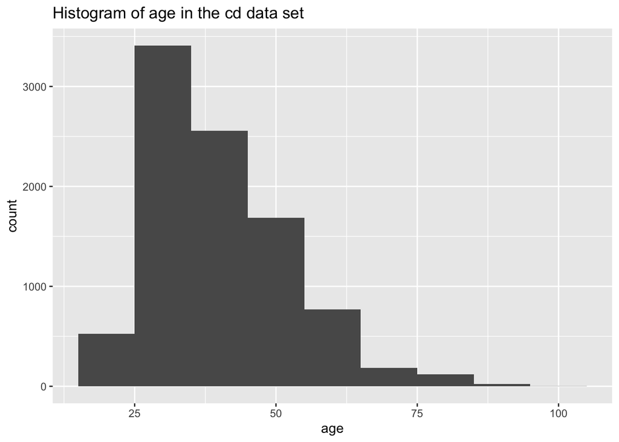

```r
cd %>%
  ggplot(aes(x = age)) +
  geom_histogram(binwidth = 10) +
  ggtitle("Histogram of age in the cd data set")
```

### 2.1.2 duration

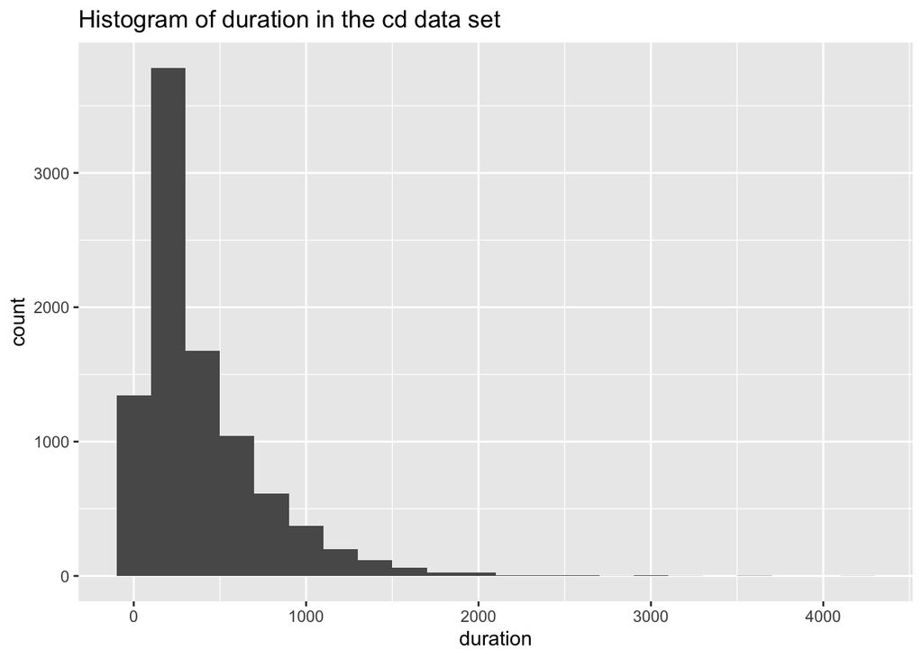

```r
cd %>%
  ggplot(aes(x = duration)) +
  geom_histogram(binwidth = 200) +
  ggtitle("Histogram of duration in the cd data set")
```

### 2.1.3 campaign

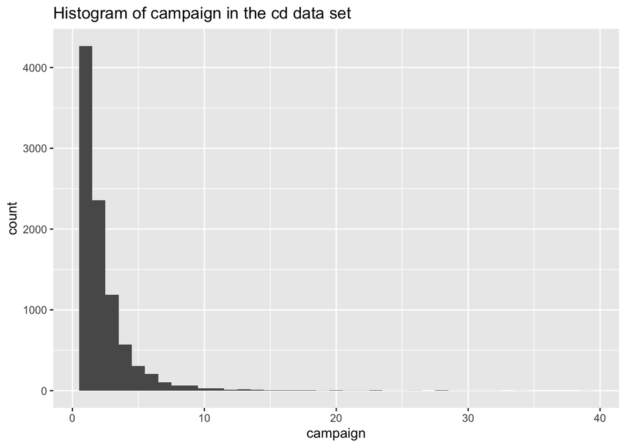

```r
cd %>%
  ggplot(aes(x = campaign)) +
  geom_histogram(binwidth = 1) +
  ggtitle("Histogram of campaign in the cd data set")
```

### 2.1.4 pdays

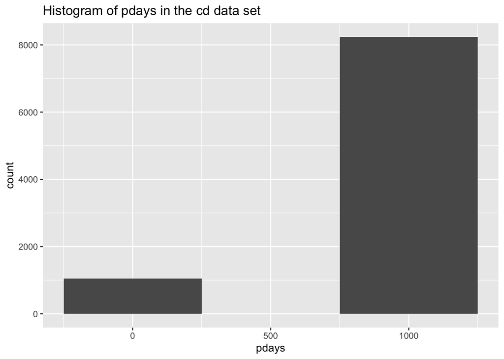

```r
cd %>%
  ggplot(aes(x = pdays)) +
  geom_histogram(binwidth = 500) +
  ggtitle("Histogram of pdays in the cd data set")
```

## 2.2 Create boxplot

### 2.2.1 age

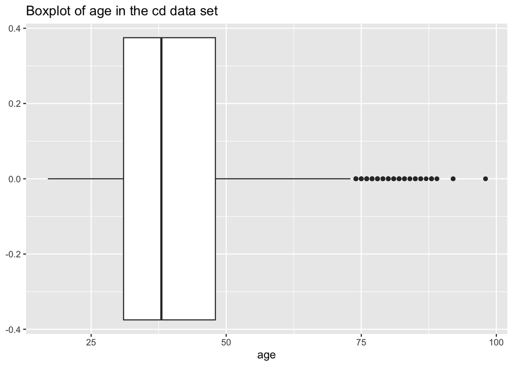

```r
cd %>%
 ggplot(aes(x=age)) +
 geom_boxplot() +
 ggtitle('Boxplot of age in the cd data set')
```

### 2.2.2 duration

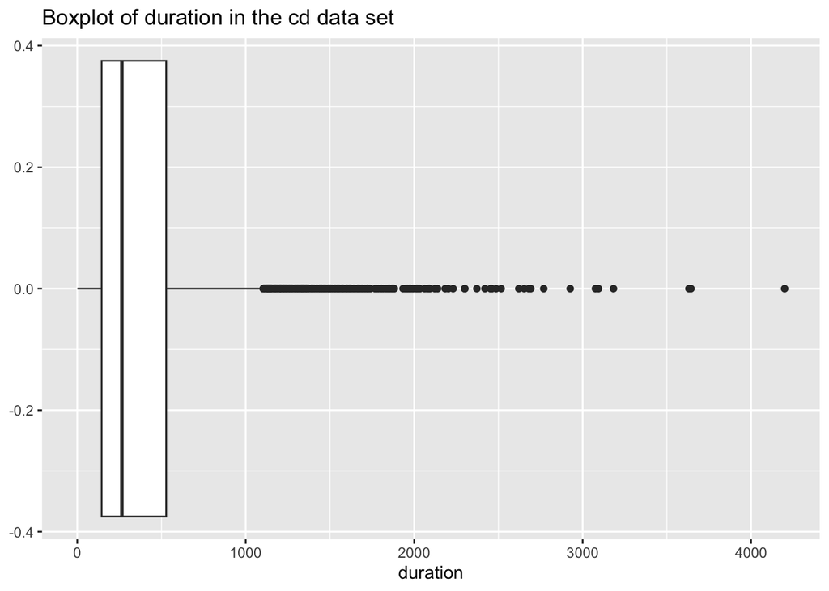

```r
cd %>%
 ggplot(aes(x=duration)) +
 geom_boxplot() +
 ggtitle('Boxplot of duration in the cd data set')
```

### 2.2.3 campaign

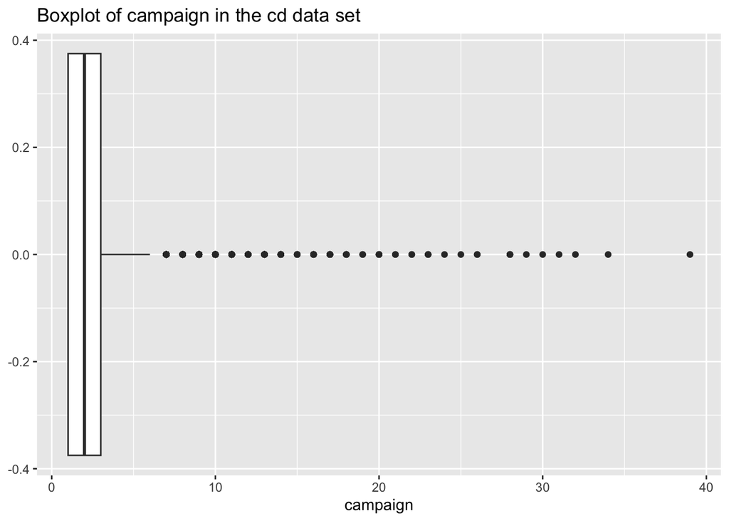

```r
cd %>%
 ggplot(aes(x=campaign)) +
 geom_boxplot() +
 ggtitle('Boxplot of campaign in the cd data set')
```

### 2.2.4 pdays

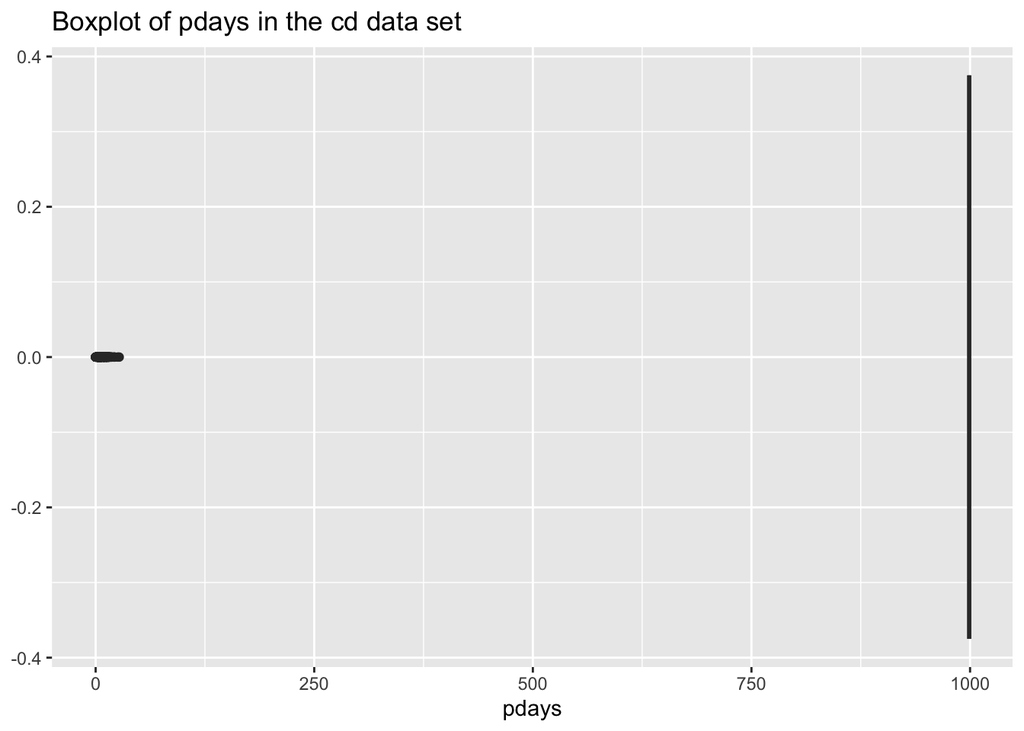

```r
cd %>%
 ggplot(aes(x=pdays)) +
 geom_boxplot() +
 ggtitle('Boxplot of pdays in the cd data set')
```

## 2.3 Show deciles

```r
cd %>%
  select(age, duration, campaign, pdays) %>%
  map(~ quantile(.x, probs = seq(0, 1, 0.1), na.rm = TRUE))
```

```
## $age
##   0%  10%  20%  30%  40%  50%  60%  70%  80%  90% 100%
##   17   27   30   33   35   38   41   46   51   57   98
##
## $duration
##   0%  10%  20%  30%  40%  50%  60%  70%  80%  90% 100%
##    1   80  124  167  211  265  340  452  615  860 4199
##
## $campaign
##   0%  10%  20%  30%  40%  50%  60%  70%  80%  90% 100%
##    1    1    1    1    1    2    2    2    3    4   39
##
## $pdays
##   0%  10%  20%  30%  40%  50%  60%  70%  80%  90% 100%
##    0   11  999  999  999  999  999  999  999  999  999
```

# 3 Explore factor variables

## 3.1 Show the count and proportion for each level of the factor variables y, job, education and poutcome

### 3.1.1 y

```r
cd %>%
  group_by(y) %>%
  summarize(n = n()) %>%
  mutate(prop = n/sum(n))
```

```
## # A tibble: 2 × 3
##   y         n  prop
##   <fct> <int> <dbl>
## 1 no     4640   0.5
## 2 yes    4640   0.5
```

### 3.1.2 job

```r
cd %>%
  group_by(job) %>%
  summarize(n = n()) %>%
  mutate(prop = n/sum(n))
```

```
## # A tibble: 12 × 3
##    job               n    prop
##    <fct>         <int>   <dbl>
##  1 admin.         2517 0.271
##  2 blue-collar    1769 0.191
##  3 entrepreneur    308 0.0332
##  4 housemaid       216 0.0233
##  5 management      651 0.0702
##  6 retired         595 0.0641
##  7 self-employed   306 0.0330
##  8 services        773 0.0833
##  9 student         358 0.0386
## 10 technician     1459 0.157
## 11 unemployed      248 0.0267
## 12 unknown          80 0.00862
```

### 3.1.3 education

```r
cd %>%
  group_by(education) %>%
  summarize(n = n()) %>%
  mutate(prop = n/sum(n))
```

```
## # A tibble: 8 × 3
##   education               n     prop
##   <fct>               <int>    <dbl>
## 1 basic.4y              895 0.0964
## 2 basic.6y              458 0.0494
## 3 basic.9y             1177 0.127
## 4 high.school          2102 0.227
## 5 illiterate              6 0.000647
## 6 professional.course  1190 0.128
## 7 university.degree    3007 0.324
## 8 unknown               445 0.0480
```

### 3.1.4 poutcome

```r
cd %>%
  group_by(poutcome) %>%
  summarize(n = n()) %>%
  mutate(prop = n/sum(n))
```

```
## # A tibble: 3 × 3
##   poutcome        n  prop
##   <fct>       <int> <dbl>
## 1 failure      1074 0.116
## 2 nonexistent  7244 0.781
## 3 success       962 0.104
```

## 3.2 Show a bar plot of the variable’s counts y, job, education and poutcome

### 3.2.1 y

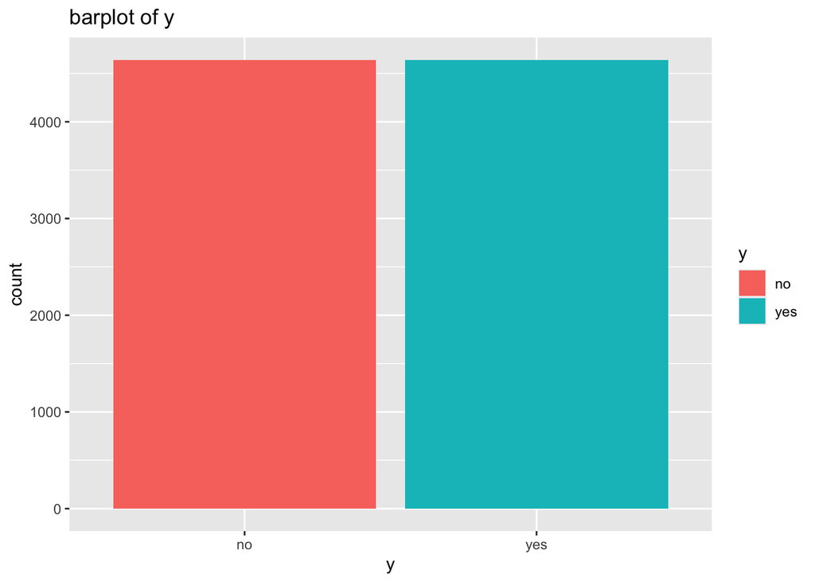

```r
cd %>%
  ggplot() +
  geom_bar(aes(x=y,fill=y)) +
  ggtitle('barplot of y')
```

### 3.2.2 job

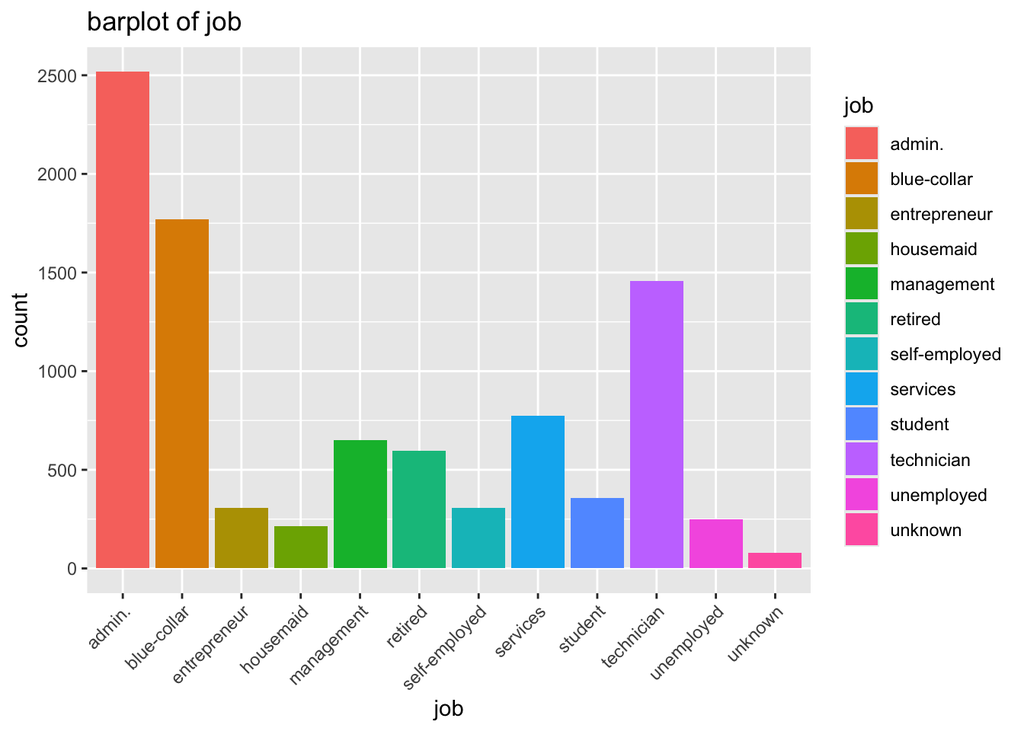

```r
cd %>%
  ggplot() +
  geom_bar(aes(x=job,fill=job)) +
  ggtitle('barplot of job') +
  theme(axis.text.x = element_text(angle = 45, hjust = 1))
```

### 3.2.3 education

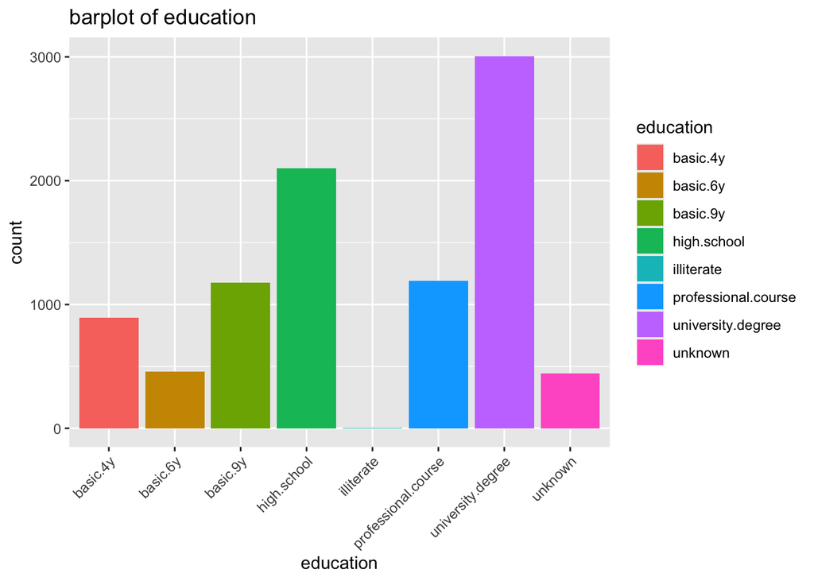

```r
cd %>%
  ggplot() +
  geom_bar(aes(x=education,fill=education)) +
  ggtitle('barplot of education') +
  theme(axis.text.x = element_text(angle = 45, hjust = 1))
```

### 3.2.4 poutcome

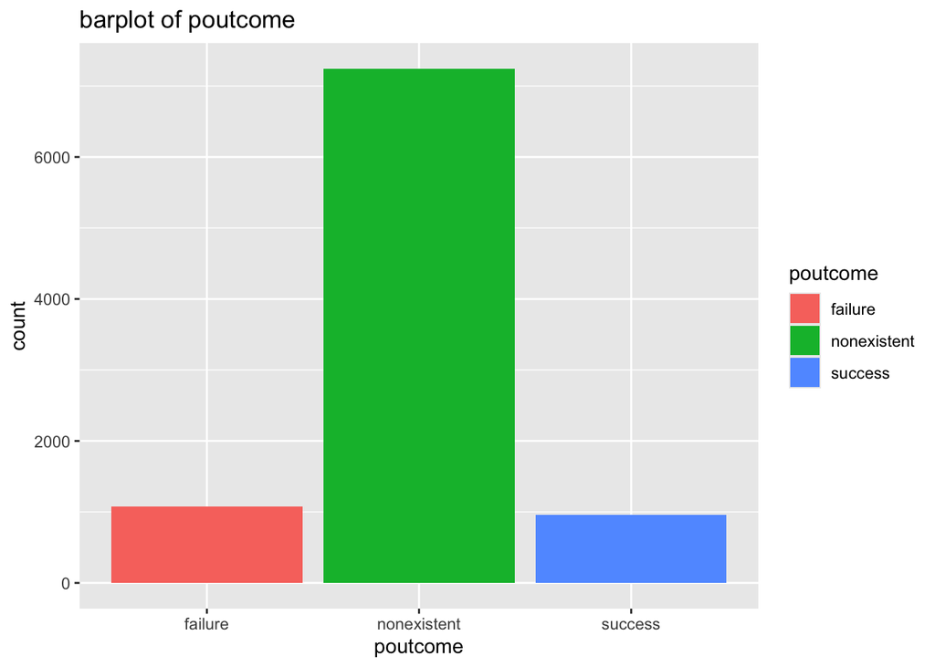

```r
cd %>%
  ggplot() +
  geom_bar(aes(x=poutcome,fill=poutcome)) +
  ggtitle('barplot of poutcome')
```

# 4 Explore relationships amongst multiple variables

## 4.1 Use cor and pairs.panels to display correlations for these seven numeric variables – age, duration, campaign, pdays, euribor3m, emp.var.rate, and nr.employed

### 4.1.1 cor

```r
cd %>%
  select(age, duration, campaign, pdays, euribor3m, emp.var.rate, nr.employed) %>%
  cor()
```

```
##                       age    duration     campaign       pdays   euribor3m
## age           1.000000000 -0.02072651  0.003690016 -0.05351616 -0.04462745
## duration     -0.020726510  1.00000000 -0.025872465  0.02893622  0.05733951
## campaign      0.003690016 -0.02587247  1.000000000  0.08930062  0.17512283
## pdays        -0.053516156  0.02893622  0.089300624  1.00000000  0.38773934
## euribor3m    -0.044627449  0.05733951  0.175122827  0.38773934  1.00000000
## emp.var.rate -0.049052629  0.07144035  0.185736186  0.33488799  0.95840218
## nr.employed  -0.074686516  0.05823209  0.176972215  0.47499217  0.94054583
##              emp.var.rate nr.employed
## age           -0.04905263 -0.07468652
## duration       0.07144035  0.05823209
## campaign       0.18573619  0.17697221
## pdays          0.33488799  0.47499217
## euribor3m      0.95840218  0.94054583
## emp.var.rate   1.00000000  0.86752989
## nr.employed    0.86752989  1.00000000
```

### 4.1.2 pairs.panels

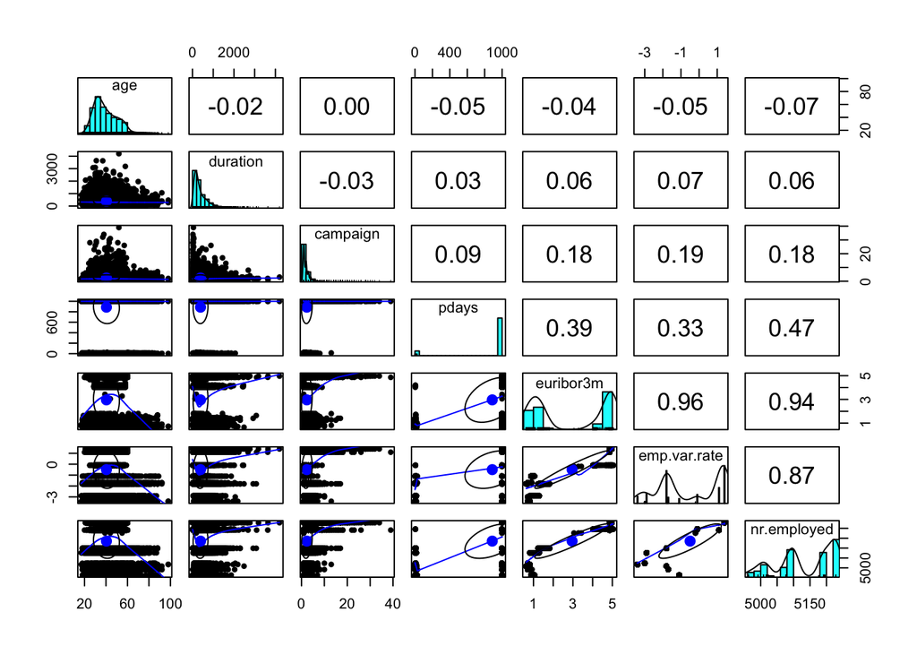

```r
cd %>%
  select(age, duration, campaign, pdays, euribor3m, emp.var.rate, nr.employed) %>%
  pairs.panels()
```

## 4.2 For each of these numeric variables - duration, emp.var.rate, cons.price.idx, and cons.conf.idx.

### 4.2.1 Show a boxplot of this numeric variable by y

#### 4.2.1.1 duration

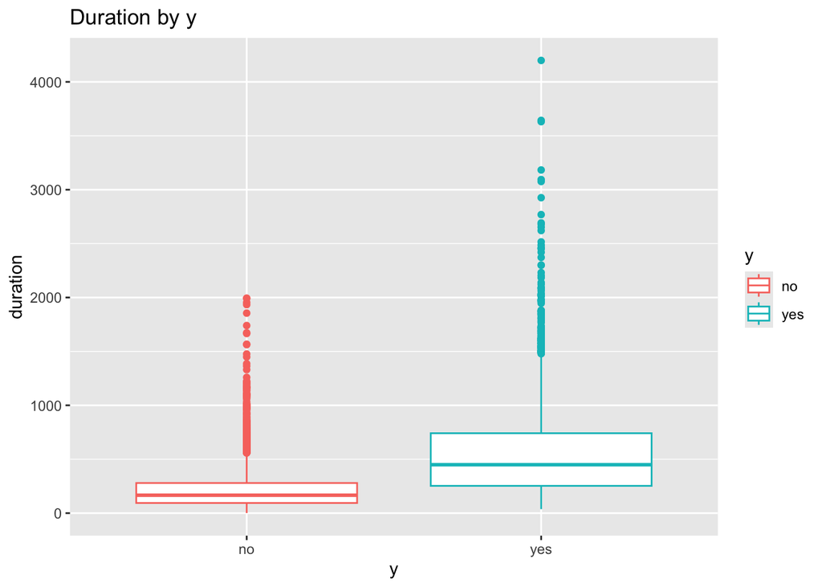

```r
cd %>%
  ggplot(aes(x = y, y = duration, color = y)) +
  geom_boxplot() +
  ggtitle("Duration by y")
```

#### 4.2.1.2 emp.var.rate

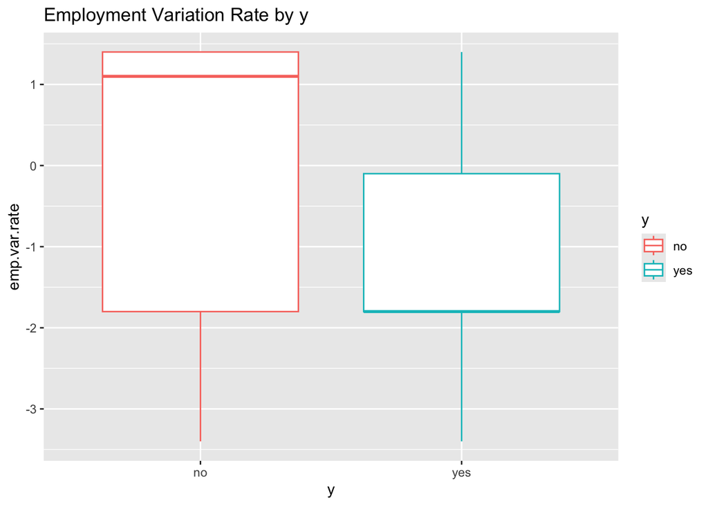

```r
cd %>%
  ggplot(aes(x = y, y = emp.var.rate, color = y)) +
  geom_boxplot() +
  ggtitle("Employment Variation Rate by y")
```

#### 4.2.1.3 cons.price.idx

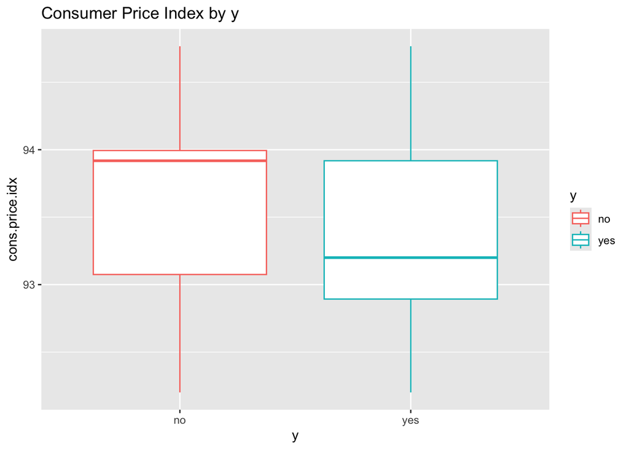

```r
cd %>%
  ggplot(aes(x = y, y = cons.price.idx, color = y)) +
  geom_boxplot() +
  ggtitle("Consumer Price Index by y")
```

#### 4.2.1.4 cons.conf.idx

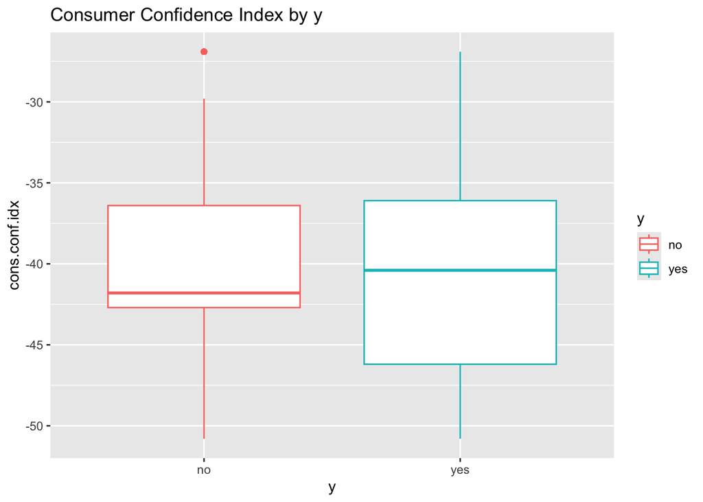

```r
cd %>%
  ggplot(aes(x = y, y = cons.conf.idx, color = y)) +
  geom_boxplot() +
  ggtitle("Consumer Confidence Index by y")
```

### 4.2.2 Use the aggregate function with ‘summary’ to aggregate this variable by y. The output should be the six number statistics (i.e. min., 1st quantile, median, mean, 3rd quantile, and max.) of the variable (e.g., duration)aggregated by “yes” and “no” respectively of y

#### 4.2.2.1 duration

```r
aggregate(duration~y, summary, data = cd)
```

```
##     y duration.Min. duration.1st Qu. duration.Median duration.Mean
## 1  no        1.0000          94.0000        166.0000      221.5323
## 2 yes       37.0000         253.0000        449.0000      553.1912
##   duration.3rd Qu. duration.Max.
## 1         279.2500     1994.0000
## 2         741.2500     4199.0000
```

#### 4.2.2.2 emp.var.rate

```r
aggregate(emp.var.rate~y, summary, data = cd)
```

```
##     y emp.var.rate.Min. emp.var.rate.1st Qu. emp.var.rate.Median
## 1  no        -3.4000000           -1.8000000           1.1000000
## 2 yes        -3.4000000           -1.8000000          -1.8000000
##   emp.var.rate.Mean emp.var.rate.3rd Qu. emp.var.rate.Max.
## 1         0.2409052            1.4000000         1.4000000
## 2        -1.2334483           -0.1000000         1.4000000
```

#### 4.2.2.3 cons.price.idx

```r
aggregate(cons.price.idx~y, summary, data = cd)
```

```
##     y cons.price.idx.Min. cons.price.idx.1st Qu. cons.price.idx.Median
## 1  no            92.20100               93.07500              93.91800
## 2 yes            92.20100               92.89300              93.20000
##   cons.price.idx.Mean cons.price.idx.3rd Qu. cons.price.idx.Max.
## 1            93.60397               93.99400            94.76700
## 2            93.35439               93.91800            94.76700
```

#### 4.2.2.4 cons.conf.idx

```r
aggregate(cons.conf.idx~y, summary, data = cd)
```

```
##     y cons.conf.idx.Min. cons.conf.idx.1st Qu. cons.conf.idx.Median
## 1  no          -50.80000             -42.70000            -41.80000
## 2 yes          -50.80000             -46.20000            -40.40000
##   cons.conf.idx.Mean cons.conf.idx.3rd Qu. cons.conf.idx.Max.
## 1          -40.64647             -36.40000          -26.90000
## 2          -39.78978             -36.10000          -26.90000
```

# 5 Observations

Here are my findings from my exploration.

## 5.1 How much data do we have?

The dataset contains 9,280 observations and 21 variables. This means there are 9,280 rows and 21 columns in the data. Each row represents one customer/contact record, and each column represents one variable about the customer, campaign contact, economic conditions, or the final response variable `y`.

## 5.2 Shape and structure of the data

Before transformation, several variables were stored as character variables. These included categorical variables such as `job`, `marital`, `education`, `default`, `housing`, `loan`, `contact`, `month`, `day_of_week`, `poutcome`, and `y`. These were converted to factor variables because they represent categories rather than continuous numeric values.

After transforming the character variables to factors, the dataset contains a mix of numeric and factor variables. The numeric variables include variables such as `age`, `duration`, `campaign`, `pdays`, `emp.var.rate`, `cons.price.idx`, `cons.conf.idx`, `euribor3m`, and `nr.employed`. The factor variables describe categorical information such as job type, education level, previous campaign outcome, and whether the customer subscribed to the term deposit.

## 5.3 Distribution of numeric variables

The variable `age` appears to be centered around middle-aged adults, with most observations falling in the adult working-age range. The histogram and boxplot show that age has some older outliers, but the overall distribution is not extremely spread out.

The variable `duration` is strongly right-skewed. Most calls are relatively short, but there are some much longer calls that appear as outliers in the boxplot. This suggests that a small number of customers had much longer contact durations than the majority.

The variable `campaign` is also right-skewed. Most customers were contacted only a small number of times during the campaign, while a smaller number of customers were contacted many times. The boxplot shows outliers for customers with unusually high campaign contact counts.

The variable `pdays` has an unusual distribution. Many observations have the same high value, likely representing customers who were not previously contacted. This makes the distribution less continuous than variables such as `age` or `duration`.

The deciles support these observations because they show how the values are spread across the dataset. For example, the lower and middle deciles for variables like `campaign` and `duration` are relatively small, while the upper deciles and maximum values are much larger, showing right-skewness.

## 5.4 Distribution of factor variables

The response variable `y` has two levels: `yes` and `no`. Because this is the balanced version of the CD dataset, the counts for `yes` and `no` are approximately equal. This is useful for modeling because the target variable is not dominated by one class.

The variable `job` has several categories. Some job groups appear much more frequently than others. The bar plot shows which job categories are most common in the dataset.

The variable `education` also has multiple levels. Some education categories are more common than others, and the bar plot makes it easier to compare the relative frequency of each education group.

The variable `poutcome` shows the outcome of the previous marketing campaign. The count table and bar plot show that some previous outcomes are much more common than others. This variable may be useful because it gives information about whether the customer had a successful or unsuccessful outcome in a prior campaign.

## 5.5 Relationships between numeric variables

The correlation matrix and `pairs.panels()` plot show relationships among the numeric variables `age`, `duration`, `campaign`, `pdays`, `euribor3m`, `emp.var.rate`, and `nr.employed`.

One important trend is that the economic variables appear to be strongly related to each other. For example, `euribor3m`, `emp.var.rate`, and `nr.employed` show noticeable correlations. This makes sense because they all describe economic or employment conditions.

The variable `duration` does not appear to be strongly correlated with most of the other numeric variables. However, based on the boxplots by `y`, `duration` appears to differ between customers who subscribed and customers who did not. Customers with `y = yes` appear to have longer call durations than customers with `y = no`.

The variable `campaign` appears to have a weaker relationship with the response variable. Customers contacted many times do not necessarily appear more likely to subscribe. The distribution is also very skewed, with many customers contacted only a few times.

## 5.6 Boxplots and aggregate summaries by y

The boxplot of `duration` by `y` shows one of the clearest differences between the `yes` and `no` groups. Customers who subscribed to the term deposit generally had longer call durations. The aggregate summary supports this because the mean and median duration for `y = yes` are higher than the mean and median duration for `y = no`.

The boxplot of `emp.var.rate` by `y` also shows differences between the two groups. The distribution of employment variation rate appears different for customers who subscribed compared to customers who did not.

The boxplot of `cons.price.idx` by `y` shows some difference between the groups, but the separation may not be as strong as with `duration`.

The boxplot of `cons.conf.idx` by `y` also shows differences in the distribution between `yes` and `no`, suggesting that consumer confidence may have some relationship with whether a customer subscribed.

## 5.7 Interesting trends

One interesting trend is that call duration appears to be strongly related to the response variable `y`. Customers who subscribed tended to have longer calls. This makes intuitive sense because a customer who is interested in the product may stay on the phone longer.

Another interesting trend is that the economic variables are related to each other. Variables such as `euribor3m`, `emp.var.rate`, and `nr.employed` appear to move together. These variables may provide similar information, so it would be important to watch for multicollinearity if building a predictive model.

The `pdays` variable also stands out because many observations appear to have the same value. This suggests that the variable may include a special code for customers who were not previously contacted. Because of this, it may need special attention when used in modeling.

## 5.8 Variables that may be useful for predicting y

If I were trying to predict the response variable `y`, I would expect `duration` to be one of the most useful variables because the boxplot and aggregate summary show a clear difference between the `yes` and `no` groups.

I would also expect `poutcome` to be useful because the outcome of a previous campaign may help predict whether a customer subscribes in the current campaign.

The economic variables, including `emp.var.rate`, `cons.price.idx`, `cons.conf.idx`, `euribor3m`, and `nr.employed`, may also be useful because they describe the broader economic environment at the time of contact. The correlation analysis shows that some of these variables are related to each other, so a model may not need all of them.

Other factor variables such as `job` and `education` may also help predict `y`, since different customer groups may respond differently to marketing campaigns.

Overall, the variables I would most suspect to be useful for predicting `y` are `duration`, `poutcome`, `emp.var.rate`, `euribor3m`, and possibly `nr.employed`, along with selected demographic variables such as `job` and `education`.